# Arithmetic Operators

# Scatter Plots

. Relative distribution of Item weight and its visibility

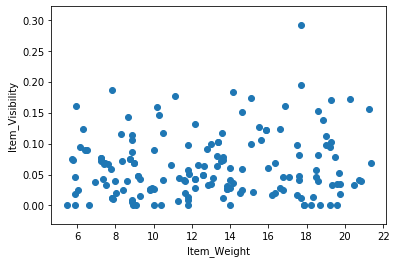

```python
# set label of axes
plt.xlabel('Item_Weight')
plt.ylabel('Item_Visibility')

# plot
plt.scatter(data_BM["Item_Weight"][:200], data_BM["Item_Visibility"][:200])
```

# Bubble Plots

```
. Relative distribution of Sales, item price and item visibility
```

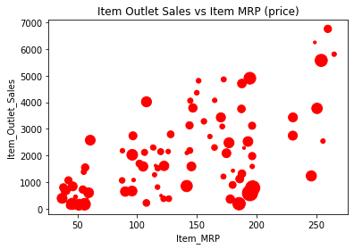

```python
# set label of axes
plt.xlabel('Item_MRP')
plt.ylabel('Item_Outlet_Sales')

# set title
plt.title('Item Outlet Sales vs Item MRP (price)')

# plot
plt.scatter(data_BM["Item_MRP"][:100], data_BM["Item_Outlet_Sales"][:100], s = data_BM["Item_Visibility"][:100] * 1000, c = 'red');
```

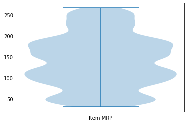

```python
data = data_BM[['Item_Weight', 'Item_MRP']]

# generate subplots
fig, ax = plt.subplots()

# add labels to x axis
plt.xticks(ticks=[1,2], labels=['Item Weight', 'Item MRP'])

# make the violinplot
plt.violinplot(data.values);
```

[figure not shown]

```python
data = data_BM[['Item_Weight', 'Item_MRP']]

# create outlier point shape
red_diamond = dict(markerfacecolor='r', marker='D')

# generate subplots
fig, ax = plt.subplots()

# make the boxplot
plt.boxplot(data.values, labels=['Item Weight', 'Item MRP (price)'], flierprops=red_diamond);
```

```python
# importing the required libraries
import pandas as pd
import numpy as np

# importing matplotlib
import matplotlib.pyplot as plt

# display plots in the notebook itself
%matplotlib inline
```

```python
pwd
```

```
'C:\\Users\\dashd'
```

```python
cd C:\Users\dashd\Desktop\Python for Data Science
```

```
C:\Users\dashd\Desktop\Python for Data Science
```

```python
data_BM = pd.read_csv('./bigmart_data.csv')
data_BM.head()
```

|  | Item_Identifier | Item_Weight | Item_Fat_Content | Item_Visibility | Item_Type | Item_MRP | Outlet_Identifier | Outlet_Establishment_Year | Outlet_Size | Outlet_Location_Type | Outlet_Type | Item_Outlet_Sales |
| --- | --- | --- | --- | --- | --- | --- | --- | --- | --- | --- | --- | --- |
| 0 | FDA15 | 9.30 | Low Fat | 0.016047 | Dairy | 249.8092 | OUT049 | 1999 | Medium | Tier 1 | Supermarket Type1 | 3735.1380 |
| 1 | DRC01 | 5.92 | Regular | 0.019278 | Soft Drinks | 48.2692 | OUT018 | 2009 | Medium | Tier 3 | Supermarket Type2 | 443.4228 |
| 2 | FDN15 | 17.50 | Low Fat | 0.016760 | Meat | 141.6180 | OUT049 | 1999 | Medium | Tier 1 | Supermarket Type1 | 2097.2700 |
| 3 | FDX07 | 19.20 | Regular | 0.000000 | Fruits and Vegetables | 182.0950 | OUT010 | 1998 | NaN | Tier 3 | Grocery Store | 732.3800 |
| 4 | NCD19 | 8.93 | Low Fat | 0.000000 | Household | 53.8614 | OUT013 | 1987 | High | Tier 3 | Supermarket Type1 | 994.7052 |

# Visualization with Seaborn

```python
import seaborn as sns
sns.set()
sns.set(style = "darkgrid")

import warnings
warnings.filterwarnings("ignore")
```

```python
# read the dataset
data_BM = pd.read_csv('./bigmart_data.csv')
# drop the null values
data_BM = data_BM.dropna(how = 'any')
# multiple Item_Visibility by 100 to increase size
data_BM['Visibility_Scaled'] = data_BM['Item_Visibility'] * 100
# view the top result
data_BM.head()
```

|  | Item_Identifier | Item_Weight | Item_Fat_Content | Item_Visibility | Item_Type | Item_MRP | Outlet_Identifier | Outlet_Establishment_Year | Outlet_Size | Outlet_Location_Type | Outlet_Type | Item_Outlet_Sales | Visibility_Scaled |
| --- | --- | --- | --- | --- | --- | --- | --- | --- | --- | --- | --- | --- | --- |
| 0 | FDA15 | 9.300 | Low Fat | 0.016047 | Dairy | 249.8092 | OUT049 | 1999 | Medium | Tier 1 | Supermarket Type1 | 3735.1380 | 1.604730 |
| 1 | DRC01 | 5.920 | Regular | 0.019278 | Soft Drinks | 48.2692 | OUT018 | 2009 | Medium | Tier 3 | Supermarket Type2 | 443.4228 | 1.927822 |
| 2 | FDN15 | 17.500 | Low Fat | 0.016760 | Meat | 141.6180 | OUT049 | 1999 | Medium | Tier 1 | Supermarket Type1 | 2097.2700 | 1.676007 |
| 4 | NCD19 | 8.930 | Low Fat | 0.000000 | Household | 53.8614 | OUT013 | 1987 | High | Tier 3 | Supermarket Type1 | 994.7052 | 0.000000 |
| 5 | FDP36 | 10.395 | Regular | 0.000000 | Baking Goods | 51.4008 | OUT018 | 2009 | Medium | Tier 3 | Supermarket Type2 | 556.6088 | 0.000000 |

# Creating basic plots

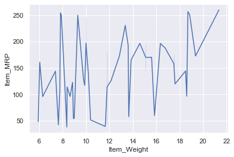

```python
# Line Chart (line plot using lineplot())
sns.lineplot(x = "Item_Weight", y = "Item_MRP", data = data_BM[:50]);
```

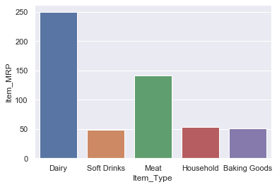

```python
# Bar Chart
sns.barplot(x = "Item_Type", y = "Item_MRP", data = data_BM[:5])
```

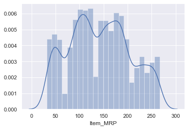

```python
# Histogram
sns.distplot(data_BM['Item_MRP'])
```

[figure not shown]

```python
# Box plots
sns.boxplot(data_BM = ['Item_Outlet_Sales'], orient = 'vertical')
```

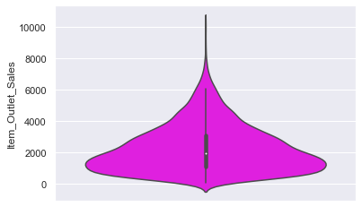

```python
# Violin plot
sns.violinplot(data_BM['Item_Outlet_Sales'], orient = 'vertical', color = 'magenta')
```

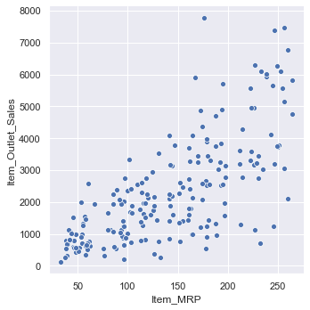

```python
# scatter plot
sns.relplot(x = 'Item_MRP', y = 'Item_Outlet_Sales', data = data_BM[:200], kind = 'scatter');
```

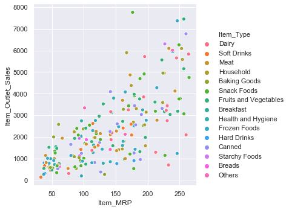

```python
# Hue semantic
sns.relplot(x = "Item_MRP", y = "Item_Outlet_Sales", hue = "Item_Type", data = data_BM[:200])
```

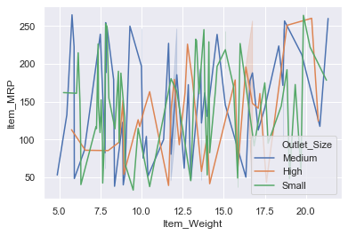

```python
# different line plots for different categories of the Outlet_Size
sns.lineplot(x= "Item_Weight", y = "Item_MRP", hue = "Outlet_Size", data = data_BM[:150]);
```

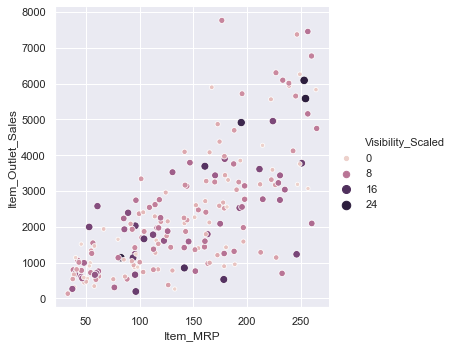

```python
# bubble plot
sns.relplot(x = 'Item_MRP', y = 'Item_Outlet_Sales', data = data_BM[:200], kind = 'scatter', size = 'Visibility_Scaled', hue = 'Visibility_Scaled');
```

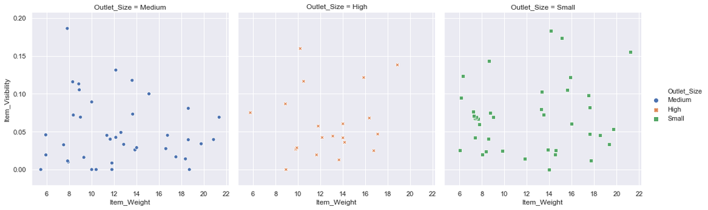

```python
# subplots for each of the category of Outlet_Size
sns.relplot(x="Item_Weight", y="Item_Visibility",hue='Outlet_Size',style='Outlet_Size',col='Outlet_Size',data=data_BM[:100]);
```

# Advance categorical plots in seaborn

# Categorical scatterplots

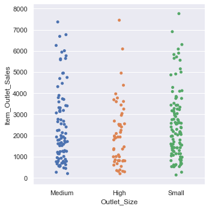

```python
# Strip plot
sns.catplot(x = "Outlet_Size", y = "Item_Outlet_Sales", kind = 'strip', data = data_BM[:250]);
```

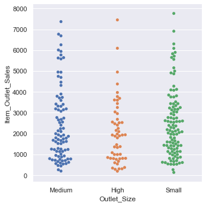

```python
# Swarm plot
sns.catplot(x = "Outlet_Size", y = "Item_Outlet_Sales", kind = 'swarm', data = data_BM[:250]);
```

# Categorical distribution plots

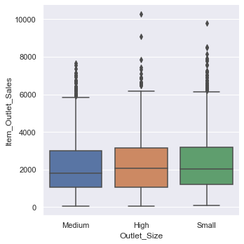

```python
# Box plots
sns.catplot(x = "Outlet_Size", y = "Item_Outlet_Sales", kind = 'box', data = data_BM);
```

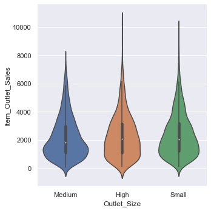

```python
# Violin plots
sns.catplot(x = "Outlet_Size", y = "Item_Outlet_Sales", kind = "violin", data = data_BM);
```

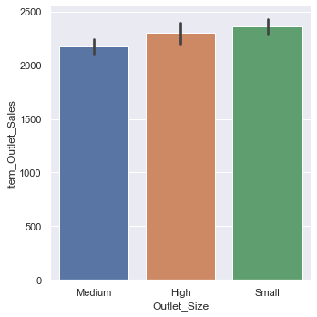

```python
# Bar plots
sns.catplot(x = "Outlet_Size", y = "Item_Outlet_Sales", kind = "bar", data = data_BM);
```

# Density Plots

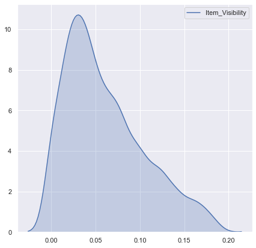

```python
# distribution of Item Visibility
plt.figure(figsize = (7,7))
sns.kdeplot(data_BM["Item_Visibility"], shade = True);
```

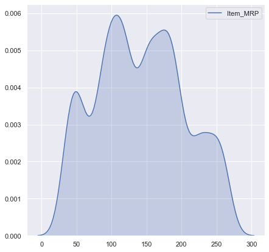

```python
# distribution of Item MRP
plt.figure(figsize = (7,7))
sns.kdeplot(data_BM["Item_MRP"], shade = True);
```

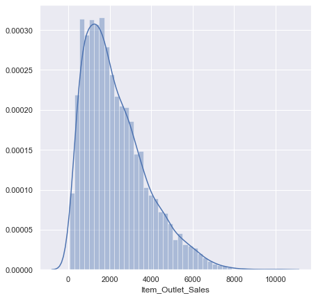

```python
# Combine histogram and density plot
plt.figure(figsize = (7,7))
sns.distplot(data_BM["Item_Outlet_Sales"]);
```

# Pair plots

```python
iris = sns.load_dataset("iris")
iris.head()
```

|  | sepal_length | sepal_width | petal_length | petal_width | species |
| --- | --- | --- | --- | --- | --- |
| 0 | 5.1 | 3.5 | 1.4 | 0.2 | setosa |
| 1 | 4.9 | 3.0 | 1.4 | 0.2 | setosa |
| 2 | 4.7 | 3.2 | 1.3 | 0.2 | setosa |
| 3 | 4.6 | 3.1 | 1.5 | 0.2 | setosa |
| 4 | 5.0 | 3.6 | 1.4 | 0.2 | setosa |

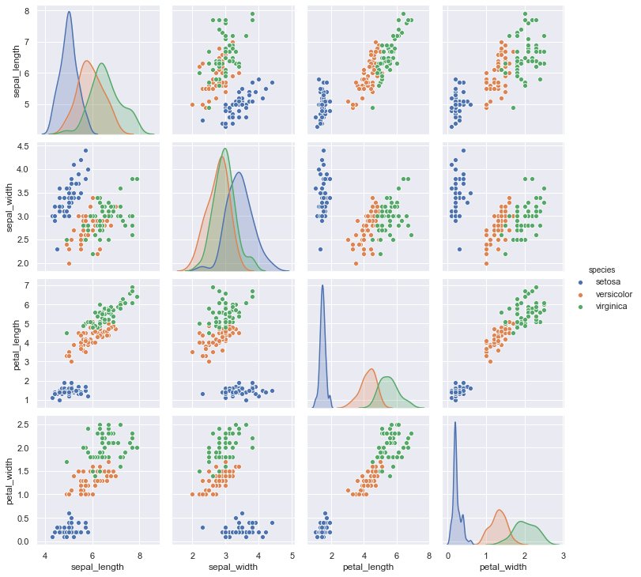

```python
# Visializing the multidimensional relationships among the samples is as easy as calling sns.pairplot
sns.pairplot(iris, hue = "species", height = 2.5);
```

# Extract Information Using Regular Expression (RegEx)

```python
# normal string vs raw string
path = "C:\desktop\nathan" # string
print("string:", path)
```

```
string: C:\desktop
athan
```

```python
# r expression to create raw string
path = r"C:\desktop\nathan"  # raw string
print("raw string:", path)
```

```
raw string: C:\desktop\nathan
```

# 1- re.match()

```python
import re

# match a word at the beginning of a string

result = re.match('Analytics', r'Analytics Vidhya is the largest data science community of India')
print(result)

result_2 = re.match('largest', r'Analytics Vidhya is the largest data science community of India')
print(result_2)
```

```
<re.Match object; span=(0, 9), match='Analytics'>
None
```

```python
# Since output of the re.match is an object, we will use group() function to get the matched expression
print(result.group())
```

```
Analytics
```

# 2- re.search()

```python
# Matches the single occurence of a pattern in the entire string

# search for the pattern "founded" in a given string
result = re.search('founded', r'Andrew NG founded Coursera. He also founded deeplearning.ai')
print(result.group())
```

```
founded
```

# 3- re.findall()

```python
# It will return all the occurences of the pattern from the string. I would recommend you to use re.findall() always, it can work like both re.search() and re.match().
result = re.findall('founded', r'Andrew NG founded Coursera. He also founded deeplearning.ai')
print(result)
```

```
['founded', 'founded']
```

# Special Sequences

```
- These are used to extract different kinds of information form a given text
```

# 1- \b returns a match where the specified pattern is at the end of a word.

```python
str = r'Analytics Vidhya is the largest Analytics community of India'

# check if there is any word that ends with "est"
x = re.findall(r"est\b", str)
print(x)
```

```
['est']
```

# 2- \d returns a match where the string contains digits (numbers from 0-9)

```python
str = "2 million monthly visits in Jan'19."

# check if the string contains any digits
x = re.findall("\d", str)
print(x)

if (x):
    print("Yes, there is at least one match!")
else:
    print("No match")
```

```
['2', '1', '9']
Yes, there is at least one match!
```

```python
str = "2 million monthly visits in Jan'19."

# check if the string contains any digits
# adding '+' after '\d' will continue to extract digits till encounters a space
x = re.findall("\d+", str)
print(x)

if (x):
    print("Yes, there is at least one match!")
else:
    print("No match")
```

```
['2', '19']
Yes, there is at least one match!
```

# 3- \D returns a match where the string does not contain any digit.

```python
str = "2 million monthly visits in Jan'19."

# check if the word character does not contain any digit(numbers from 0-9)
x = re.findall("\D", str)
print(x)

if (x):
    print("Yes, there is at least one match!")
else:
    print("No match")
```

```
[' ', 'm', 'i', 'l', 'l', 'i', 'o', 'n', ' ', 'm', 'o', 'n', 't', 'h', 'l', 'y', ' ', 'v', 'i', 's', 'i', 't', 's', ' ', 'i', 'n', ' ', 'J', 'a', 'n', "'", '.']
Yes, there is at least one match!
```

```python
str = "2 million monthly visits in Jan'19"

# check if the word character does not contain any digit(numbers from 0-9)
x = re.findall("\D+", str)
print(x)

if (x):
    print("Yes, there is at least one match!")
else:
    print("No match")
```

```
[" million monthly visits in Jan'"]
Yes, there is at least one match!
```

# 4- \w helps in extraction of alphanumeric characters only (characters from a to z, digits from 0-9, and the underscore _ character

```python
str = "2 million monthly_visits!"

x = re.findall("\w", str)
print(x)

if (x):
    print("Yes, there is at least one match!")
else:
    print("No match")
```

```
['2', 'm', 'i', 'l', 'l', 'i', 'o', 'n', 'm', 'o', 'n', 't', 'h', 'l', 'y', '_', 'v', 'i', 's', 'i', 't', 's']
Yes, there is at least one match!
```

```python
str = "2 million monthly_visits!"

x = re.findall("\w+", str)
print(x)

if (x):
    print("Yes, there is at least one match!")
else:
    print("No match")
```

```
['2', 'million', 'monthly_visits']
Yes, there is at least one match!
```

# 5- \W returns a match at every non alphanumeric character

```python
str = "2 million monthly_visits9!"

x = re.findall("\W", str)
print(x)

if (x):
    print("Yes, there is at least one match!")
else:
    print("No match")
```

```
[' ', ' ', '!']
Yes, there is at least one match!
```

# Metacharacters

```
- Metacharacters are characters with a special meaning
```

# 1- (.) matches ant charater (except newline character)

```python
str = "rohan and rohit recently published a research paper!"

# search for a string that starts rith "ro", followed by a certain number of characters

x = re.findall("ro.", str)
x2 = re.findall("ro...", str)

print(x)
print(x2)
```

```
['roh', 'roh']
['rohan', 'rohit']
```

# 2- (^) starts with given pattern.

```python
str = "Data Science"

# check if the string starts with 'Data':
x = re.findall("^Data", str)

if (x):
    print("Yes, the string starts with 'Data'")
else:
    print("No match")

# print(x)
```

```
Yes, the string starts with 'Data'
```

```python
# try with different string
str2 = "Big Data"

# check if the string starts with 'Data':
x2 = re.findall("^Data", str2)

if (x2):
    print("Yes, the string starts with 'Data'")
else:
    print("No match")

# print(x2)
```

```
No match
```

# 3- ($) ends with given pattern.

```python
str= "Data Science"

# check if the string ends with 'Science'
x = re.findall("Science$", str)

if (x):
    print("Yes, the string ends with 'Science'")
else:
    print("No match")

# print(x)
```

```
Yes, the string ends with 'Science'
```

# 4- (*) matches for zero or more occurences of the pattern to the left of it

```python
str = "easy easssy eay ey"

#Check if the string contains "ea" followed by 0 or more "s" characters and ending with y
x = re.findall("eas*y", str)

print(x)

if (x):
  print("Yes, there is at least one match!")
else:
  print("No match")
```

```
['easy', 'easssy', 'eay']
Yes, there is at least one match!
```

# 5- (+) matches one or more occurences of the pattern to the left of it

```python
#Check if the string contains "ea" followed by 1 or more "s" characters and ends with y
x = re.findall("eas+y", str)

print(x)

if (x):
  print("Yes, there is at least one match!")
else:
  print("No match")
```

```
['easy', 'easssy']
Yes, there is at least one match!
```

# 6- (?) matches zero or one occurence of the pattern left to it

```python
x = re.findall("eas?y",str)

print(x)

if (x):
  print("Yes, there is at least one match!")
else:
  print("No match")
```

```
['easy', 'eay']
Yes, there is at least one match!
```

# 7- (|) either or

```python
str = "Analytics Vidhya is the largest data science community of India"

#Check if the string contains either "data" or "India":

x = re.findall("data|India", str)

print(x)

if (x):
  print("Yes, there is at least one match!")
else:
  print("No match")
```

```
['data', 'India']
Yes, there is at least one match!
```

```python
# try with a different string
str = "Analytics Vidhya is one of the largest data science communities"

#Check if the string contains either "data" or "India":

x = re.findall("data|India", str)

print(x)

if (x):
  print("Yes, there is at least one match!")
else:
  print("No match")
```

```
['data']
Yes, there is at least one match!
```

# Sets

```
- A set is a bunch of characters inside a pair of square brackets [].
```

```python
str = "Analytics Vidhya is the largest data science community of India"

#Check for the characters y, d, or h, in the above string
x = re.findall("[ydh]", str)

print(x)

if (x):
  print("Yes, there is at least one match!")
else:
  print("No match")
```

```
['y', 'd', 'h', 'y', 'h', 'd', 'y', 'd']
Yes, there is at least one match!
```

```python
str = "Analytics Vidhya is the largest data science community of India"

#Check for the characters between a and g, in the above string
x = re.findall("[a-g]", str)

print(x)

if (x):
  print("Yes, there is at least one match!")
else:
  print("No match")
```

```
['a', 'c', 'd', 'a', 'e', 'a', 'g', 'e', 'd', 'a', 'a', 'c', 'e', 'c', 'e', 'c', 'f', 'd', 'a']
Yes, there is at least one match!
```

```python
str = "Mars' average distance from the Sun is roughly 230 million km and its orbital period is 687 (Earth) days."

# extract the numbers starting with 0 to 4 from in the above string
x = re.findall(r"\b[0-4]\d+", str)

print(x)

if (x):
  print("Yes, there is at least one match!")
else:
  print("No match")
```

```
['230']
Yes, there is at least one match!
```

# [^] check whether string has other characters mentioned after ^

```python
str = "Analytics Vidhya is the largest data sciece community of India"

#Check if every word character has characters than y, d, or h

x = re.findall("[^ydh]", str)

print(x)

if (x):
  print("Yes, there is at least one match!")
else:
  print("No match")
```

```
['A', 'n', 'a', 'l', 't', 'i', 'c', 's', ' ', 'V', 'i', 'a', ' ', 'i', 's', ' ', 't', 'e', ' ', 'l', 'a', 'r', 'g', 'e', 's', 't', ' ', 'a', 't', 'a', ' ', 's', 'c', 'i', 'e', 'c', 'e', ' ', 'c', 'o', 'm', 'm', 'u', 'n', 'i', 't', ' ', 'o', 'f', ' ', 'I', 'n', 'i', 'a']
Yes, there is at least one match!
```

[a-zA-Z0-9] check whether string has terms starting with characters other than aphanumeric.

```python
str = "@AV Largest Data Science community #AV!!"

# extract words that start with a special character
x = re.findall("[^a-zA-Z0-9 ]\w+", str)

print(x)
```

```
['@AV', '#AV']
```

# Solve Complex Queries

```
- Let us try solving some complex queries using regex.
- Extracting Emails IDs
```

# Extracting Email IDs

```python
str = 'Send a mail to rohan.1997@gmail.com, smith_david34@yahoo.com and priya@yahoo.com about the meeting @2PM'

# \w matches any alpha numeric character
# + for repeats a character one or more times
#x = re.findall('\w+@\w+\.com', str)
x = re.findall('[a-zA-Z0-9._-]+@\w+\.com', str)

# Printing of List
print(x)
```

```
['rohan.1997@gmail.com', 'smith_david34@yahoo.com', 'priya@yahoo.com']
```

# Extracting Dates

```python
text = "London Olympic 2012 was held from 2012-07-27 to 2012/08/12."

# '\d{4}' repeats '\d' 4 times
match = re.findall('\d{4}.\d{2}.\d{2}', text)
print(match)
```

```
['2012-07-27', '2012/08/12']
```

```python
# extract dates with varying lengths
text="London Olympic 2012 was held from 27 July 2012 to 12 August 2012."

#'\w{3,10}' repeats '\w' 3 to 10 times
match = re.findall('\d{2}.\w{3,10}.\d{4}', text)

print(match)
```

```
['27 July 2012', '12 August 2012']
```

```python
text="London Olympic 2012 was held from 27 Jul 2012 to 12-Aug-2012."

match = re.findall('\d{2}.\w{3}.\d{4}', text)

print(match)
```

```
['27 Jul 2012', '12-Aug-2012']
```

# Extracting Title from Names - Titanic Dataset

```python
import pandas as pd

# load dataset
data = pd.read_csv('titanic.csv')
```

```python
data.head()
```

|  | PassengerId | Survived | Pclass | Name | Sex | Age | SibSp | Parch | Ticket | Fare | Cabin | Embarked |
| --- | --- | --- | --- | --- | --- | --- | --- | --- | --- | --- | --- | --- |
| 0 | 1 | 0 | 3 | Braund, Mr. Owen Harris | male | 22.0 | 1 | 0 | A/5 21171 | 7.2500 | NaN | S |
| 1 | 2 | 1 | 1 | Cumings, Mrs. John Bradley (Florence Briggs Th... | female | 38.0 | 1 | 0 | PC 17599 | 71.2833 | C85 | C |
| 2 | 3 | 1 | 3 | Heikkinen, Miss. Laina | female | 26.0 | 0 | 0 | STON/O2. 3101282 | 7.9250 | NaN | S |
| 3 | 4 | 1 | 1 | Futrelle, Mrs. Jacques Heath (Lily May Peel) | female | 35.0 | 1 | 0 | 113803 | 53.1000 | C123 | S |
| 4 | 5 | 0 | 3 | Allen, Mr. William Henry | male | 35.0 | 0 | 0 | 373450 | 8.0500 | NaN | S |

```python
# print a few passenger names
data['Name'].head(10)
```

```
0                              Braund, Mr. Owen Harris
1    Cumings, Mrs. John Bradley (Florence Briggs Th...
2                               Heikkinen, Miss. Laina
3         Futrelle, Mrs. Jacques Heath (Lily May Peel)
4                             Allen, Mr. William Henry
5                                     Moran, Mr. James
6                              McCarthy, Mr. Timothy J
7                       Palsson, Master. Gosta Leonard
8    Johnson, Mrs. Oscar W (Elisabeth Vilhelmina Berg)
9                  Nasser, Mrs. Nicholas (Adele Achem)
Name: Name, dtype: object
```

# Method 1: One way is to split on the pandasdataframe and extract the title

```python
name = "Allen, Mr. William Henry"
name2 = name.split(".")
name2
```

```
['Allen, Mr', ' William Henry']
```

```python
name2[0].split(',')
```

```
['Allen', ' Mr']
```

```python
# this method might not work all the time
title=data['Name'].apply(lambda x: x.split(".")[0].split(",")[1])
title.value_counts()
```

```
 Mr              517
 Miss            182
 Mrs             125
 Master           40
 Dr                7
 Rev               6
 Col               2
 Major             2
 Mlle              2
 Don               1
 Jonkheer          1
 Mme               1
 Lady              1
 Capt              1
 Sir               1
 Ms                1
 the Countess      1
Name: Name, dtype: int64
```

# Method 2: Use RegEx to extract titles

```python
def split_it(name):
    return re.findall("\w+\.",name)[0]
```

```python
title=data['Name'].apply(lambda x: split_it(x))
title.value_counts()
```

```
Mr.          517
Miss.        182
Mrs.         125
Master.       40
Dr.            7
Rev.           6
Mlle.          2
Major.         2
Col.           2
Jonkheer.      1
Sir.           1
Mme.           1
Ms.            1
Don.           1
Countess.      1
Lady.          1
Capt.          1
Name: Name, dtype: int64
```